# Forecast daily bike rental demand using time series models

Roquez Walker

2023-07-06

# About Data Analysis Report

This RMarkdown file contains the report of the data analysis done for the project on forecasting daily bike rental demand using time series models in R. It contains analysis such as data exploration, summary statistics and building the time series models. The final report was completed on Thu Jul 6 18:19:33 2023.

**Data Description:**

This dataset contains the daily count of rental bike transactions between years 2011 and 2012 in Capital bikeshare system with the corresponding weather and seasonal information.

**Data Source:** https://archive.ics.uci.edu/ml/datasets/bike+sharing+dataset

**Relevant Paper:**

Fanaee-T, Hadi, and Gama, Joao, ‘Event labeling combining ensemble detectors and background knowledge’, Progress in Artificial Intelligence (2013): pp. 1-15, Springer Berlin Heidelberg

# Task One: Load and explore the data

## Loading data and install packages

```r
## Import required packages
  library("tidyverse")
```

```r
  library("timetk")
  library("ggplot2")
#forecast allows tsclean function to remove outliers from time series
##also allows predictions to be made on time series data
  library("forecast")
#TTR allows smoothing moving average function with SMA()
  library("TTR")
#aTSA package includes functions to check if a time series is stationary
  library("aTSA")
#Linear Models
  library("lmtest")
  library("fUnitRoots")
```

```r
library(readr)
day <- read_csv("bike+sharing+dataset/day.csv",
    col_types = cols(instant = col_integer(),
        dteday = col_date(format = "%Y-%m-%d"),
        season = col_integer(), yr = col_integer(),
        mnth = col_integer(), holiday = col_integer(),
        weekday = col_integer(), workingday = col_integer(),
        weathersit = col_integer()))
View(day)
glimpse(day)
```

```
## Rows: 731
## Columns: 16
## $ instant    <int> 1, 2, 3, 4, 5, 6, 7, 8, 9, 10, 11, 12, 13, 14, 15, 16, 17, …
## $ dteday     <date> 2011-01-01, 2011-01-02, 2011-01-03, 2011-01-04, 2011-01-05…
## $ season     <int> 1, 1, 1, 1, 1, 1, 1, 1, 1, 1, 1, 1, 1, 1, 1, 1, 1, 1, 1, 1,…
## $ yr         <int> 0, 0, 0, 0, 0, 0, 0, 0, 0, 0, 0, 0, 0, 0, 0, 0, 0, 0, 0, 0,…
## $ mnth       <int> 1, 1, 1, 1, 1, 1, 1, 1, 1, 1, 1, 1, 1, 1, 1, 1, 1, 1, 1, 1,…
## $ holiday    <int> 0, 0, 0, 0, 0, 0, 0, 0, 0, 0, 0, 0, 0, 0, 0, 0, 1, 0, 0, 0,…
## $ weekday    <int> 6, 0, 1, 2, 3, 4, 5, 6, 0, 1, 2, 3, 4, 5, 6, 0, 1, 2, 3, 4,…
## $ workingday <int> 0, 0, 1, 1, 1, 1, 1, 0, 0, 1, 1, 1, 1, 1, 0, 0, 0, 1, 1, 1,…
## $ weathersit <int> 2, 2, 1, 1, 1, 1, 2, 2, 1, 1, 2, 1, 1, 1, 2, 1, 2, 2, 2, 2,…
## $ temp       <dbl> 0.3441670, 0.3634780, 0.1963640, 0.2000000, 0.2269570, 0.20…
## $ atemp      <dbl> 0.3636250, 0.3537390, 0.1894050, 0.2121220, 0.2292700, 0.23…
## $ hum        <dbl> 0.805833, 0.696087, 0.437273, 0.590435, 0.436957, 0.518261,…
## $ windspeed  <dbl> 0.1604460, 0.2485390, 0.2483090, 0.1602960, 0.1869000, 0.08…
## $ casual     <dbl> 331, 131, 120, 108, 82, 88, 148, 68, 54, 41, 43, 25, 38, 54…
## $ registered <dbl> 654, 670, 1229, 1454, 1518, 1518, 1362, 891, 768, 1280, 122…
## $ cnt        <dbl> 985, 801, 1349, 1562, 1600, 1606, 1510, 959, 822, 1321, 126…
```

## Describing and exploring the data

### Examining the bike rental data

#### Seasons: Winter 1, Fall 2, Summer 3, Spring 4

```r
day %>%
    group_by(season) %>%
      summarize(Seasonal_Avg_Bikes_Rented = mean(cnt), Casual_Renters = mean(casual), Registered_Renters = mean(registered), Avg_Temp = as.integer(mean(temp)*100))
```

```
## # A tibble: 4 × 5
##   season Seasonal_Avg_Bikes_Rented Casual_Renters Registered_Renters Avg_Temp
##    <int>                     <dbl>          <dbl>              <dbl>    <int>
## 1      1                     2604.           335.              2269.       29
## 2      2                     4992.          1106.              3886.       54
## 3      3                     5644.          1203.              4442.       70
## 4      4                     4728.           729.              3999.       42
```

#### Months

```r
day %>%
    group_by(mnth) %>%
      summarize(Monthly_Avg_Bikes_Rented = mean(cnt), Casual_Renters = mean(casual), Registered_Renters = mean(registered), Avg_Temp = as.integer(mean(temp)*100))
```

```
## # A tibble: 12 × 5
##     mnth Monthly_Avg_Bikes_Rented Casual_Renters Registered_Renters Avg_Temp
##    <int>                    <dbl>          <dbl>              <dbl>    <int>
##  1     1                    2176.           194.              1982.       23
##  2     2                    2655.           263.              2393.       29
##  3     3                    3692.           717.              2975.       39
##  4     4                    4485.          1013.              3472.       46
##  5     5                    5350.          1214.              4136.       59
##  6     6                    5772.          1232.              4541.       68
##  7     7                    5564.          1261.              4303.       75
##  8     8                    5664.          1162.              4502.       70
##  9     9                    5767.          1172.              4594.       61
## 10    10                    5199.           964.              4235.       48
## 11    11                    4247.           610.              3637.       36
## 12    12                    3404.           350.              3054.       32
```

#### Correlations in Rentals

```r
day %>%
  summarize(Temp_Rental_corr = cor(x = temp, y = cnt), Humidity_Rental_corr = cor(x = hum, y  = cnt), Season_Renatl_corr = cor(x = season, y  = cnt),Month_Rental_corr = cor(x = mnth, y  = cnt),)
```

```
## # A tibble: 1 × 4
##   Temp_Rental_corr Humidity_Rental_corr Season_Renatl_corr Month_Rental_corr
##              <dbl>                <dbl>              <dbl>             <dbl>
## 1            0.627               -0.101              0.406             0.280
```

# Task Two: Create interactive time series plots

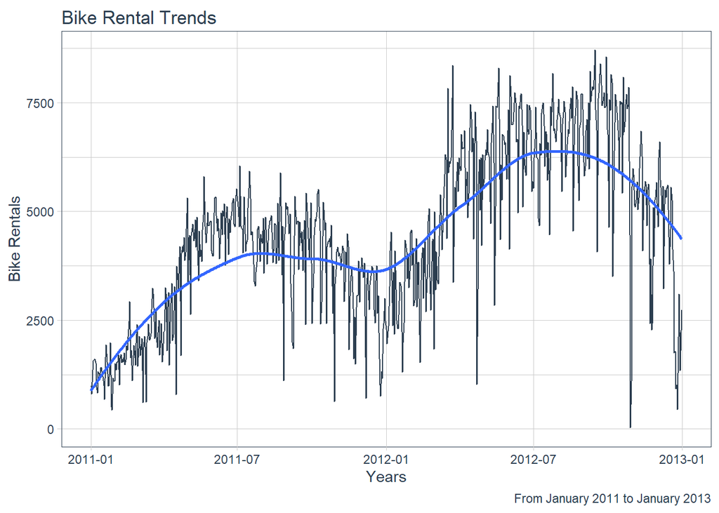

```r
## Read about the timetk package
# ?timetk
day %>%
    plot_time_series(dteday,cnt,
                   .interactive = FALSE,
                   .plotly_slider = TRUE,
                   ) +
        labs(title = "Bike Rental Trends", caption = "From January 2011 to January 2013") +
        xlab("Years") + ylab("Bike Rentals")
```

# Task Three: Smooth time series data

### Converting columns to vectors

```r
dates <- day$dteday
count <- day$cnt
```

### Locating Outliers

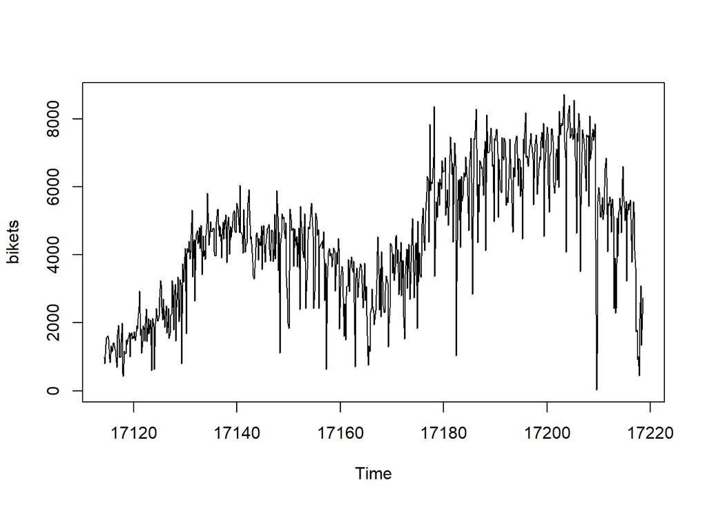

```r
#creates time series object
bikets <- ts(day$cnt, start = dates, frequency = 7)
plot(bikets)
```

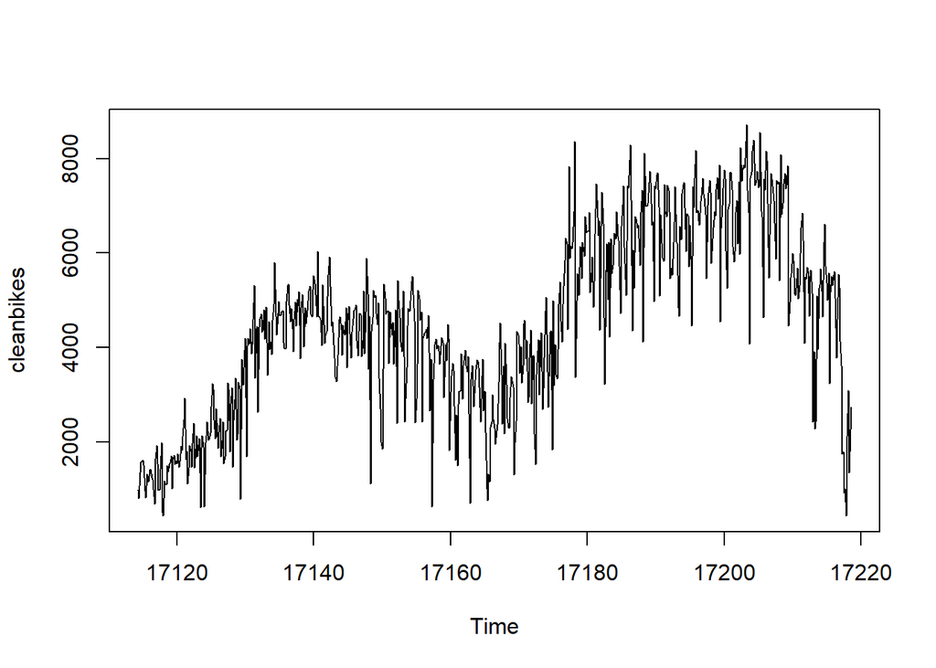

```r
#identifies and replaces outliers
cleanbikes <- tsclean(bikets, replace.missing = TRUE)
plot(cleanbikes)
```

####Smooth time series data using Holt-winter’s additive method

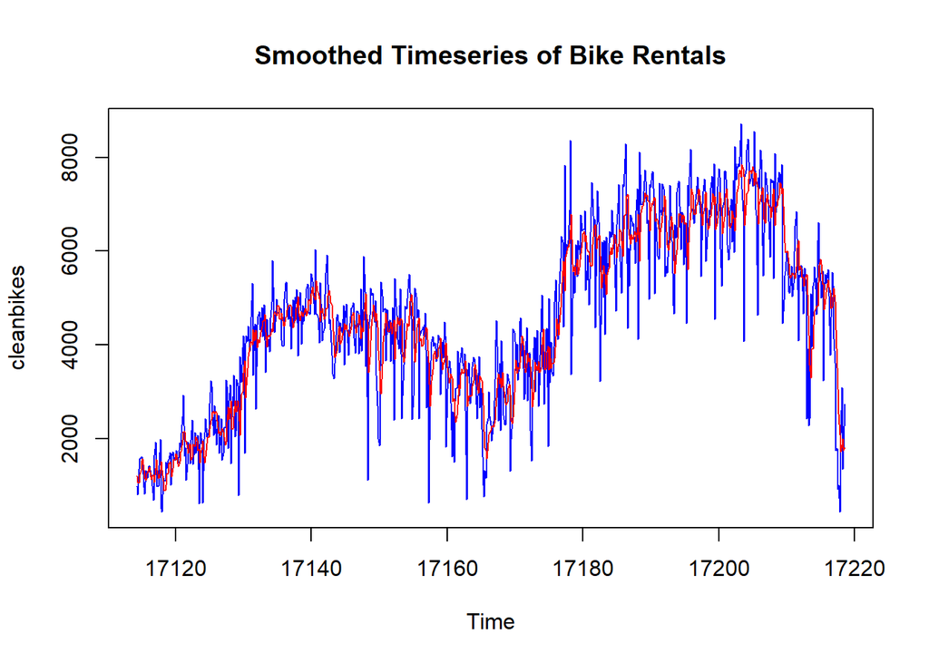

```r
fit <- hw(cleanbikes, seasonal = "additive")
plot.ts(cleanbikes, main = "Smoothed Timeseries of Bike Rentals", col = "blue")
lines(fitted(fit), col = "red")
```

####Smooth time series data using Simple Moving area

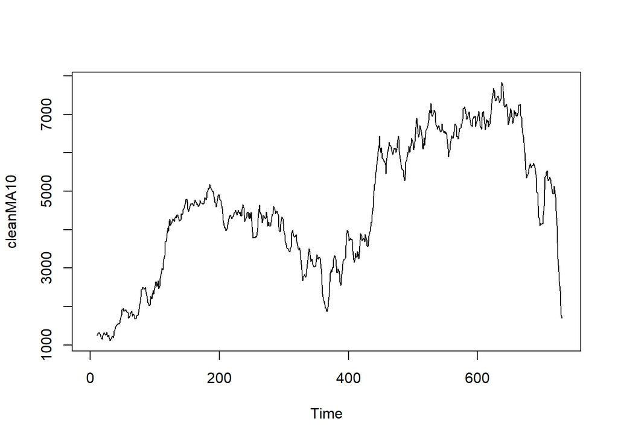

```r
cleanMA10 <- SMA(cleanbikes, n = 10)
plot.ts(cleanMA10)
```